# IRT with Stan

July 11, 2016

## Outline

1. IRT with **edstan**
2. Constructing basic IRT models with **Stan**
3. Extending IRT models with **Stan**

## Part 1

1. **IRT with edstan**
   - Overview of **edstan**
   - Example analysis with the Rasch model
   - Fitting other **edstan** models
2. Constructing basic IRT models with **Stan**
3. Extending IRT models with **Stan**

## The purpose of **edstan**

The purpose is lower the start up costs of doing IRT with **Stan**.

**edstan** assists by providing

- *.stan* files for several common models
- **R** functions to help fit and interpret the models

## Installing and loading **edstan**

**rstan** should be installed first. Then **edstan** can be installed from Github.

```r
install.packages("devtools")
devtools::install_github("danielcfurr/edstan")
```

Then both should be loaded.

```r
# Load rstan and edstan
library(rstan)
library(edstan)
rstan_options(auto_write = TRUE) # Optional
options(mc.cores = parallel::detectCores()) # Optional
```

## **edstan** models

[output not shown]

## **edstan** functions (1/5)

| Function | Purpose |
| --- | --- |
| `irt_data()` | Prepares data for fitting |
| `labelled_integer()` | Create vector of consecutive integers |
| `irt_stan()` | Wrapper for running MCMC |
| `print_irt_stan()` | Show table of output |

## **edstan** functions (2/5)

`irt_data()` returns a data list in the correct format for the **edstan** models.

For wide-form data, it is used as follows:

`irt_data(response_matrix, W)`

- `response_matrix` is a matrix of scored responses.
- `W` (optional) is a matrix of person covariates.

For long-form data, it is used as follows:

`irt_data(y, ii, jj, W)`

- `y` is the scored response vector.
- `ii` is an index for items.
- `jj` is an index for persons.

## **edstan** functions (3/5)

`labelled_integer()` returns a vector of consecutive integers. It helps in creating indices like `ii` and `jj`.

It is used as follows:

`labelled_integer(x)`

- `x` is a vector of identifiers.

`x` can be a numeric, character, or factor variable.

The elements of the returned vector are labelled with their original values.

## **edstan** functions (4/5)

`irt_stan()` is a wrapper for `stan()` and returns a `stanfit` object.

It is used as follows:

`irt_stan(data_list, model, ...)`

- `data_list` is the result of `irt_data()`.
- `model` (optional) is the file name for one of the edstan models.
- `...` allows arguments to be passed to `stan()`, such as:
  - `chains`: the number of MCMC chains.
  - `iter`: the number of iterations per chain.

## **edstan** functions (5/5)

`print_irt_stan()` provides summaries of parameter posteriors. It is an alternative to `print()` for `stanfit` objects.

It is used as follows:

`print_irt_stan(fit, data_list, probs)`

## Example dataset: Verbal agression (1/3)

24 items, for example:

- "A bus fails to stop for me. I would want to curse."
- "I miss a train because a clerk gave me faulty information. I would scold."
- "The grocery store closes just as I am about to enter. I would shout."

Polytomous responses:

- 2 = "Yes"
- 1 = "Perhaps"
- 0 = "No"

## Example dataset: Verbal agression (2/3)

24 items, for example:

- "A bus fails to stop for me. I would want to curse."
- "I miss a train because a clerk gave me faulty information. I would scold."
- "The grocery store closes just as I am about to enter. I would shout."

Uses a \(3 \times 2 \times 2\) item design:

- Behavior: *curse* versus *scold* versus *shout*.
- Mode: *do* versus *want*.
- Blame: *other* versus *self*.

## Example dataset: Verbal agression (3/3)

- \(I = 24\) items and \(J = 316\) persons.
- Original and dichotomized responses (`poly`, `dich`).
- Two person covariates (`anger`, `male`).
- Four item covariates (`do`, `other`, `scold`, `shout`).

```r
# View first few rows
head(aggression)
```

```
##   person item poly dich    description anger male do other scold shout
## 1      1    1    0    0   do bus curse    20    1  0     1     0     0
## 2      1    2    0    0   do bus scold    20    1  0     1     1     0
## 3      1    3    0    0   do bus shout    20    1  0     1     0     1
## 4      1    4    0    0 do train curse    20    1  0     1     0     0
## 5      1    5    0    0 do train scold    20    1  0     1     1     0
## 6      1    6    0    0 do train shout    20    1  0     1     0     1
```

## Latent regression Rasch model (1/5)

\[ \Pr(y_{ij} = 1 | \theta_j, \beta_i) = \mathrm{logit}^{-1} [ \theta_j - \beta_i ] \] \[ \theta_j | w_j \sim \mathrm{N}(w_j' \lambda, \sigma^2) \]

- \(y_{ij} = 1\) if person \(j\) responded to item \(i\) correctly.
- \(w_{j}\) is the vector of covariates for person \(j\).
- \(\beta_i\) is the difficulty for item \(i\).
- \(\theta_j\) is the ability for person \(j\).
- \(\lambda\) is the vector of latent regression coefficients.
- \(\sigma^2\) is the variance for the ability distribution.

## Latent regression Rasch model (2/5)

A latent regression may be included (or not) with any of the **edstan** models. To do this, create a matrix of covariates and pass it to `irt_data()`.

```r
# Assemble matrix of person covariates
covars <- aggression[, c("person", "anger", "male")]
covars <- unique(covars)
covars <- covars[order(covars$person), ]
W <- cbind(intercept = 1, covars[, -1])
head(W)
```

```
##     intercept anger male
## 1           1    20    1
## 25          1    11    1
## 49          1    17    0
## 73          1    21    0
## 97          1    17    0
## 121         1    21    0
```

## Latent regression Rasch model (3/5)

The data list is assembled and then the model is fit.

```r
# Make the data list
data_dich <- irt_data(y = aggression$dich,
                      ii = labelled_integer(aggression$description),
                      jj = aggression$person,
                      W = W)

# Fit the latent regression Rasch model
fit_rasch <- irt_stan(data_dich, model = "rasch_latent_reg.stan",
                      iter = 200, chains = 4)
```

## Latent regression Rasch model (4/5)

```r
# View summary of parameter posteriors
print_irt_stan(fit_rasch, data_dich, probs = c(.025, .975))
```

```
## Item 1: do bus curse
##         mean se_mean    sd  2.5% 97.5% n_eff  Rhat
## beta[1] -1.4 0.00679 0.136 -1.64 -1.12   400 0.998
##
## Item 2: do bus scold
##           mean se_mean    sd  2.5%  97.5% n_eff  Rhat
## beta[2] -0.743  0.0069 0.138 -1.01 -0.488   400 0.999
##
## Item 3: do bus shout
##           mean se_mean    sd   2.5%  97.5% n_eff  Rhat
## beta[3] -0.245  0.0063 0.126 -0.495 0.0399   400 0.998
##
## Item 4: do train curse
##          mean se_mean    sd  2.5% 97.5% n_eff Rhat
## beta[4] -1.92 0.00759 0.152 -2.23 -1.63   400    1
##
## Item 5: do train scold
##           mean se_mean    sd 2.5%  97.5% n_eff Rhat
## beta[5] -0.881  0.0059 0.118 -1.1 -0.659   400 1.01
##
## Item 6: do train shout
##           mean se_mean   sd   2.5%  97.5% n_eff Rhat
## beta[6] -0.174 0.00701 0.14 -0.449 0.0869   400    1
##
## Item 7: do store curse
##           mean se_mean    sd   2.5%  97.5% n_eff  Rhat
## beta[7] -0.699 0.00682 0.136 -0.967 -0.433   400 0.998
##
## Item 8: do store scold
##          mean se_mean    sd  2.5% 97.5% n_eff Rhat
## beta[8] 0.517 0.00642 0.128 0.277 0.781   400    1
##
## Item 9: do store shout
##         mean se_mean    sd 2.5% 97.5% n_eff Rhat
## beta[9] 1.37 0.00774 0.155 1.07  1.65   400 1.01
##
## Item 10: do operator curse
##           mean se_mean    sd  2.5%  97.5% n_eff  Rhat
## beta[10] -1.26 0.00688 0.138 -1.53 -0.999   400 0.997
##
```

[output cut: 47 more lines]

[output not shown]

…

```
##
## Item 22: want operator curse
##            mean se_mean    sd  2.5%  97.5% n_eff Rhat
## beta[22] -0.863 0.00704 0.141 -1.15 -0.607   400    1
##
## Item 23: want operator scold
##           mean se_mean    sd    2.5% 97.5% n_eff  Rhat
## beta[23] 0.223 0.00719 0.144 -0.0461 0.481   400 0.994
##
## Item 24: want operator shout
##          mean se_mean    sd 2.5% 97.5% n_eff Rhat
## beta[24] 1.86 0.00882 0.171 1.56  2.22   375    1
##
## Ability distribution
##              mean  se_mean     sd    2.5%   97.5% n_eff Rhat
## lambda[1] -1.3981 0.016313 0.3263 -2.0374 -0.7364   400 1.00
## lambda[2]  0.0577 0.000785 0.0157  0.0274  0.0861   400 1.01
## lambda[3]  0.3118 0.011648 0.1958 -0.0774  0.6718   283 1.00
## sigma      1.3705 0.004084 0.0659  1.2545  1.5031   261 1.01
```

## Latent regression Rasch model (5/5)

Check all parameters for convergence.

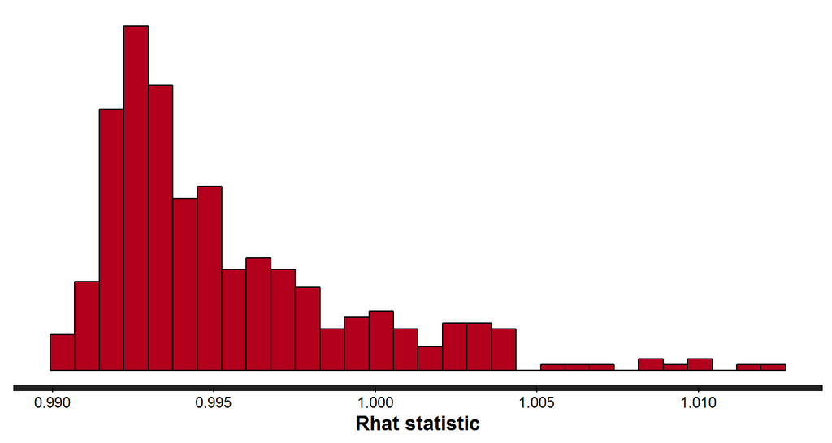

```r
# Check convergence (rhat)
stan_rhat(fit_rasch)
```

## Two-parameter logistic model

The 2PL may be fit by requesting a different **Stan** model.

```r
# Fit the latent regression 2PL model
fit_2pl <- irt_stan(data_dich, model = "2pl_latent_reg.stan",
                    iter = 200, chains = 4)
```

The latent regression may be omitted by excluding `W` when using `irt_data()`.

```r
# Make the data list without poviding W
data_noreg <- irt_data(y = aggression$dich,
                       ii = labelled_integer(aggression$description),
                       jj = aggression$person)

# Fit the 2PL without latent regression
fit_noreg <- irt_stan(data_noreg, model = "2pl_latent_reg.stan",
                      iter = 200, chains = 4)
```

## Polytomous models (1/2)

To fit the polytomous models, assemble the data list using the original responses.

```r
data_poly <- irt_data(y = aggression$poly,
                      ii = labelled_integer(aggression$description),
                      jj = aggression$person,
                      W = W)
```

## Polytomous models (2/2)

Then pass the new data list to `irt_stan()` and specify the desired model.

```r
fit_rsm <- irt_stan(data_poly, model = "rsm_latent_reg.stan",
                    iter = 300, chains = 4)

fit_pcm <- irt_stan(data_poly, model = "pcm_latent_reg.stan",
                    iter = 300, chains = 4)

fit_gpcm <- irt_stan(data_poly, model = "gpcm_latent_reg.stan",
                    iter = 300, chains = 4)

fit_grsm <- irt_stan(data_poly, model = "grsm_latent_reg.stan",
                    iter = 300, chains = 4)
```

## Part 2

1. IRT with **edstan**
2. **Constructing basic IRT models with Stan**
   - Simple Rasch model
   - Latent regression Rasch model
   - Latent regression 2PL model
3. Extending IRT models with **Stan**

## Simple Rasch model (1/3)

\[ \Pr(y_{ij} = 1 | \theta_j, \beta_i) = \mathrm{logit}^{-1} [ \theta_j - \beta_i ] \] \[ \theta_j \sim \mathrm{N}(0, \sigma^2) \]

Priors:

\[\beta_i \sim \mathrm{N}(0, 25)\] \[\sigma \sim \mathrm{Exp}(.1)\]

## Simple Rasch model (2/3)

```
data {
  int<lower=1> I;               // # questions
  int<lower=1> J;               // # persons
  int<lower=1> N;               // # observations
  int<lower=1, upper=I> ii[N];  // question for n
  int<lower=1, upper=J> jj[N];  // person for n
  int<lower=0, upper=1> y[N];   // correctness for n
}
parameters { ... }
model { ... }
```

## Simple Rasch model (3/3)

```
data { ... }
parameters {
  vector[I] beta;
  vector[J] theta;
  real<lower=0> sigma;
}
model {
  target += normal_lpdf(beta | 0, 5);
  target += normal_lpdf(theta | 0, sigma);
  target += exponential_lpdf(sigma | .1);
  target += bernoulli_logit_lpmf(y | theta[jj] - beta[ii]);
}
```

## Adding latent regression (1/3)

\[ \Pr(y_{ij} = 1 | \theta_j, \beta_i) = \mathrm{logit}^{-1} [ \theta_j - \beta_i ] \] \[ \theta_j | w_j \sim \mathrm{N}(w_j' \lambda, \sigma^2) \]

Priors:

\[\beta_1 \cdots \beta_{(I-1)} \sim \mathrm{N}(0, 25)\] \[\sigma \sim \mathrm{Exp}(.1)\] \[\lambda \sim \mathrm{unif}(-\infty, \infty)\]

Constraint:

\[\beta_I = -\sum_{i=1}^{(I-1)} \beta_i\]

## Adding latent regression (2/3)

**edstan** file: *rasch_latent_reg.stan*

```
data {
  int<lower=1> I;               // # questions
  int<lower=1> J;               // # persons
  int<lower=1> N;               // # observations
  int<lower=1, upper=I> ii[N];  // question for n
  int<lower=1, upper=J> jj[N];  // person for n
  int<lower=0, upper=1> y[N];   // correctness for n
  int<lower=1> K;               // # person covariates
  matrix[J,K] W;                // person covariate matrix
}
parameters { ... }
transformed parameters { ... }
model { ... }
```

## Adding latent regression (3/3)

```
data { ... }
parameters {
  vector[I-1] beta_free;
  vector[J] theta;
  real<lower=0> sigma;
  vector[K] lambda;
}
transformed parameters {
  vector[I] beta;
  beta = append_row(beta_free, rep_vector(-1*sum(beta_free), 1));
}
model {
  target += normal_lpdf(beta_free | 0, 5);
  target += normal_lpdf(theta |W*lambda, sigma);
  target += exponential_lpdf(sigma | .1);
  target += bernoulli_logit_lpmf(y | theta[jj] - beta[ii]);
}
```

## 2PL with latent regression (1/3)

\[ \Pr(y_{ij} = 1 | \theta_j, \alpha_i, \beta_i) = \mathrm{logit}^{-1} [ \alpha_i (\theta_j + w_j'\lambda - \beta_i) ] \] \[ \theta_j \sim \mathrm{N}(0, 1) \]

Priors:

\[\beta_1 \cdots \beta_{(I-1)} \sim \mathrm{N}(0, 25)\] \[\alpha_i \sim \mathrm{log~N}(1, 1)\] \[\lambda \sim \mathrm{unif}(-\infty, \infty)\]

Constraint:

\[\beta_I = -\sum_{i=1}^{(I-1)} \beta_i\]

## 2PL with latent regression (2/3)

**edstan** file: *2pl_latent_reg.stan*

```
data {
  int<lower=1> I;               // # questions
  int<lower=1> J;               // # persons
  int<lower=1> N;               // # observations
  int<lower=1, upper=I> ii[N];  // question for n
  int<lower=1, upper=J> jj[N];  // person for n
  int<lower=0, upper=1> y[N];   // correctness for n
  int<lower=1> K;               // # person covariates
  matrix[J,K] W;                // person covariate matrix
}
parameters { ... }
transformed parameters { ... }
model { ... }
```

## 2PL with latent regression (3/3)

```
data { ... }
parameters {
  vector<lower=0>[I] alpha;
  vector[I-1] beta_free;
  vector[J] theta;
  vector[K] lambda;
}
transformed parameters {
  vector[I] beta;
  beta = append_row(beta_free, rep_vector(-1*sum(beta_free), 1));
}
model {
  vector[J] mu;
  mu = W*lambda;
  target += lognormal_lpdf(alpha | 1, 1);
  target += normal_lpdf(beta_free | 0, 5);
  target += normal_lpdf(theta | 0, 1);
  target += bernoulli_logit_lpmf(y |
              alpha[ii].*(theta[jj] + mu[jj] - beta[ii]));
}
```

## Fit the models directly with **rstan**

The Rasch and 2PL models may be fit with `stan()` rather than `irt_stan()`, yielding equivalent results.

```r
# Assuming the .stan files are in the working directory:
# Fit Rasch latent reg model
rasch_fit <- stan("rasch_latent_reg.stan", data = data_dich,
                  iter = 200, chains = 4)

# Fit 2PL latent reg model
twopl_fit <- stan("2pl_latent_reg.stan", data = data_dich,
                  iter = 200, chains = 4)
```

## 2PL tutorial

See also an in-depth [tutorial](http://mc-stan.org/documentation/case-studies/tutorial_twopl.html) for the 2PL model.

## Part 3

1. IRT with **edstan**
2. Constructing basic IRT models with **Stan**
3. **Extending IRT models with Stan**
   - Multilevel Rasch model
   - Random item Rasch model
   - Linear logistic test model with error

## Multilevel Rasch model (1/3)

\[ \Pr(y_{ij} = 1 | \xi_s, \zeta_{sj}, \beta_i) = \mathrm{logit}^{-1} [ \xi_s + \zeta_{sj} - \beta_i ] \] \[ \zeta_{sj} \sim \mathrm{N}(0, \sigma_1^2) \] \[ \xi_s \sim \mathrm{N}(0, \sigma_2^2) \]

- \(\xi_s\) is the school-level ability for school \(s\).
- \(\zeta_{sj}\) is the person-level ability for person \(j\) in school \(s\).

## Multilevel Rasch model (2/3)

```
data {
  int<lower=1> I;               // # questions
  int<lower=1> J;               // # persons
  int<lower=1> S;               // # schools
  int<lower=1> N;               // # observations
  int<lower=1, upper=I> ii[N];  // question for n
  int<lower=1, upper=J> jj[N];  // person for n
  int<lower=1, upper=S> ss[N];  // school for n
  int<lower=0, upper=1> y[N];   // correctness for n
}
parameters { ... }
model { ... }
```

## Multilevel Rasch model (3/3)

```
data { ... }
parameters {
  vector[I] beta;
  vector[J] zeta;
  vector[S] xi;
  real<lower=0> sigma[2];
}
model {
  target += normal_lpdf(zeta | 0, sigma[1]);
  target += normal_lpdf(xi | 0, sigma[2]);
  target += bernoulli_logit_lpmf(y | xi[ss] + zeta[jj] - beta[ii]);
}
```

## Random item Rasch model (1/4)

\[ \Pr(y_{ij} = 1 | \theta_j, \beta_i) = \mathrm{logit}^{-1} [ \theta_{j} - \beta_i ] \] \[ \theta_j \sim \mathrm{N}(\mu, \sigma^2) \] \[ \beta_i \sim \mathrm{N}(0, \tau^2) \]

## Random item Rasch model (2/4)

```
data {
  int<lower=1> I;               // # questions
  int<lower=1> J;               // # persons
  int<lower=1> N;               // # observations
  int<lower=1, upper=I> ii[N];  // question for n
  int<lower=1, upper=J> jj[N];  // person for n
  int<lower=0, upper=1> y[N];   // correctness for n
}
parameters { ... }
model { ... }
```

## Random item Rasch model (3/4)

```
data { ... }
parameters {
  vector[I] beta;
  vector[J] theta;
  real mu;
  real<lower=0> sigma;
  real<lower=0> tau;
}
model {
  target += normal_lpdf(theta | mu, sigma);
  target += normal_lpdf(beta | 0, tau);
  target += bernoulli_logit_lpmf(y | theta[jj] - beta[ii]);
}
```

## Random item Rasch model (4/4)

See also a [case study](http://mc-stan.org/documentation/case-studies/hierarchical_2pl.html) for a 2PL random item model that includes a correlation between the discrimination and difficulty parameters.

## LLTM-E (1/9)

Linear logistic test model with error:

\[ \Pr(y_{ij} = 1 | \theta_j, \delta_i) = \mathrm{logit}^{-1} [ \theta_{j} - \delta_i ] \] \[ \delta_i \equiv x_i'\beta + \epsilon_i \] \[ \theta_j \sim \mathrm{N}(0, \sigma^2) \] \[ \epsilon_i \sim \mathrm{N}(0, \tau^2) \]

- \(x_i\) is a row from item covariate matrix \(X\).
- \(\beta\) is a vector of regression coefficients.
- \(\epsilon_i\) is the residual item difficulty.
- \(\delta_i\) is the composite item difficulty.

## LLTM-E (2/9)

**Stan** file: *lltme.stan*

```
data {
  int<lower=1> I;               // # questions
  int<lower=1> J;               // # persons
  int<lower=1> N;               // # observations
  int<lower=1, upper=I> ii[N];  // question for n
  int<lower=1, upper=J> jj[N];  // person for n
  int<lower=0, upper=1> y[N];   // correctness for n
  int<lower=1> K;               // # item predictors
  matrix[I,K] X;                // Item predictor matrix
}
parameters { ... }
transformed parameters { ... }
model { ... }
generated quantities { ... }
```

## LLTM-E (3/9)

```
data { ... }
parameters {
  vector[J] theta;
  vector[K] beta;
  vector[I] epsilon;
  real<lower=0> sigma;
  real<lower=0> tau;
}
transformed parameters {
  vector[I] delta;
  delta = X*beta + epsilon;
}
model {
  target += normal_lpdf(theta | 0, sigma);
  target += normal_lpdf(epsilon | 0, tau);
  target += bernoulli_logit_lpmf(y | theta[jj] - delta[ii]);
}
generated quantities { ... }
```

## LLTM-E (4/9)

```
data { ... }
parameters { ... }
transformed parameters { ... }
model { ... }
generated quantities {
  real rsq;
  rsq = variance(X*beta) / (variance(X*beta) + tau^2);
}
```

## LLTM-E (5/9)

Let's revisit the verbal aggression data.

```r
# View first few rows
head(aggression)
```

```
##   person item poly dich    description anger male do other scold shout
## 1      1    1    0    0   do bus curse    20    1  0     1     0     0
## 2      1    2    0    0   do bus scold    20    1  0     1     1     0
## 3      1    3    0    0   do bus shout    20    1  0     1     0     1
## 4      1    4    0    0 do train curse    20    1  0     1     0     0
## 5      1    5    0    0 do train scold    20    1  0     1     1     0
## 6      1    6    0    0 do train shout    20    1  0     1     0     1
```

## LLTM-E (6/9)

Make \(X\), the matrix of item covariates.

```r
# Assemble a matrix of item covariates
item_covars <- aggression[, c("item", "do", "other", "scold", "shout")]
item_covars <- unique(item_covars)
item_covars <- item_covars[order(item_covars$item), ]
X <- cbind(intercept = 1, item_covars[, -1])
head(X)
```

```
##   intercept do other scold shout
## 1         1  0     1     0     0
## 2         1  0     1     1     0
## 3         1  0     1     0     1
## 4         1  0     1     0     0
## 5         1  0     1     1     0
## 6         1  0     1     0     1
```

## LLTM-E (7/9)

Make the full data list and fit the model.

```r
# Make the data list
data_lltme <- list(I = max(aggression$item),
                   J = max(aggression$person),
                   N = nrow(aggression),
                   ii = aggression$item,
                   jj = aggression$person,
                   y = aggression$dich,
                   K = ncol(X),
                   X = X)

# Fit the LLTM-E with Stan
fit_lltme <- stan("lltme.stan", data = data_lltme,
                  iter = 200, chains = 4)
```

## LLTM-E (8/9)

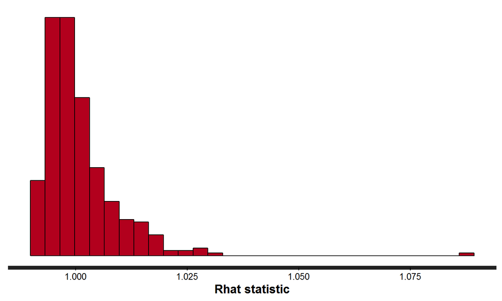

```r
# Check convergence (rhat)
stan_rhat(fit_lltme)
```

## LLTM-E (9/9)

```r
# View a summary of parameter posteriors
print(fit_lltme, pars = c("beta", "tau", "rsq", "sigma"))
```

```
## Inference for Stan model: lltme.
## 4 chains, each with iter=200; warmup=100; thin=1;
## post-warmup draws per chain=100, total post-warmup draws=400.
##
##          mean se_mean   sd  2.5%   25%   50%   75% 97.5% n_eff Rhat
## beta[1] -0.73    0.01 0.23 -1.17 -0.88 -0.74 -0.60 -0.26   262 1.00
## beta[2]  0.72    0.01 0.20  0.32  0.59  0.70  0.85  1.11   400 1.00
## beta[3] -1.07    0.01 0.19 -1.40 -1.19 -1.06 -0.95 -0.65   379 1.00
## beta[4]  1.05    0.01 0.26  0.47  0.89  1.06  1.19  1.55   340 0.99
## beta[5]  2.12    0.02 0.25  1.64  1.95  2.12  2.28  2.69   264 0.99
## tau      0.44    0.01 0.09  0.30  0.37  0.42  0.49  0.65   316 1.00
## rsq      0.86    0.00 0.06  0.70  0.83  0.88  0.90  0.93   272 1.00
## sigma    1.40    0.01 0.08  1.26  1.34  1.40  1.44  1.55   205 1.01
##
## Samples were drawn using NUTS(diag_e) at Thu Jul 07 14:57:57 2016.
## For each parameter, n_eff is a crude measure of effective sample size,
## and Rhat is the potential scale reduction factor on split chains (at
## convergence, Rhat=1).
##  The estimated Bayesian Fraction of Missing Information is a measure of
##  the efficiency of the sampler with values close to 1 being ideal.
##  For each chain, these estimates are
##  1.3 0.8 1 0.8
```